# R Notebook

```r
library(readr) #Membaca data
library(dplyr) #Data processing
library(DT) #Menampilkan tabel agar mudah dilihat di browser
library(readxl)
data10.1 <- read_excel("C:/Users/lili/Downloads/Data10Penugasan.xlsx",sheet="Sheet1")
data10.1
```

| Kab | Miskin | IPM | TPT | Gini |
| --- | --- | --- | --- | --- |
| Merauke | 10.03 | 70.09 | 2.61 | 0.380 |
| Jayawijaya | 37.22 | 58.03 | 2.39 | 0.342 |
| Jayapura | 12.44 | 71.69 | 9.68 | 0.432 |
| Nabire | 24.15 | 68.83 | 6.31 | 0.349 |
| KepulauanYapen | 26.30 | 67.66 | 5.78 | 0.400 |
| BiakNumfor | 24.57 | 72.19 | 10.42 | 10.420 |
| Paniai | 36.71 | 56.31 | 0.66 | 0.380 |
| PuncakJaya | 34.74 | 48.37 | 1.78 | 0.376 |
| Mimika | 14.26 | 74.19 | 7.51 | 0.339 |
| BovenDigoel | 19.41 | 61.53 | 3.08 | 0.448 |

[output cut: 19 more lines]

```r
datatable(data10.1, caption = "Variabel")
```

|  | Kab | Miskin | IPM | TPT | Gini |
| --- | --- | --- | --- | --- | --- |
| 1 | Merauke | 10.03 | 70.09 | 2.61 | 0.38 |
| 2 | Jayawijaya | 37.22 | 58.03 | 2.39 | 0.342 |
| 3 | Jayapura | 12.44 | 71.69 | 9.68 | 0.432 |
| 4 | Nabire | 24.15 | 68.83 | 6.31 | 0.349 |
| 5 | KepulauanYapen | 26.3 | 67.66 | 5.78 | 0.4 |
| 6 | BiakNumfor | 24.57 | 72.19 | 10.42 | 10.42 |
| 7 | Paniai | 36.71 | 56.31 | 0.66 | 0.38 |
| 8 | PuncakJaya | 34.74 | 48.37 | 1.78 | 0.376 |
| 9 | Mimika | 14.26 | 74.19 | 7.51 | 0.339 |
| 10 | BovenDigoel | 19.41 | 61.53 | 3.08 | 0.448 |

[output cut: 19 more lines]

```r
data_standardized1 <- round(scale(data10.1[,2:5]),4) #Hanya memilih kolom/variabel yang berisikan indikator yang akan digunakan
datatable(data_standardized1, caption = "Data Hasil Standardisasi")
```

| Miskin | IPM | TPT | Gini |
| --- | --- | --- | --- |
| -1.8903 | 1.1345 | -0.2015 | -0.1713 |
| 0.9362 | 0.0658 | -0.2678 | -0.1917 |
| -1.6398 | 1.2763 | 1.928 | -0.1435 |
| -0.4224 | 1.0229 | 0.9129 | -0.1879 |
| -0.1989 | 0.9192 | 0.7533 | -0.1606 |
| -0.3788 | 1.3206 | 2.1509 | 5.1964 |
| 0.8832 | -0.0866 | -0.7888 | -0.1713 |
| 0.6784 | -0.7903 | -0.4515 | -0.1735 |
| -1.4506 | 1.4979 | 1.2744 | -0.1933 |
| -0.9152 | 0.376 | -0.0599 | -0.135 |

[output cut: 19 more lines]

```r
data_standardized1
```

```
       Miskin     IPM     TPT    Gini
 [1,] -1.8903  1.1345 -0.2015 -0.1713
 [2,]  0.9362  0.0658 -0.2678 -0.1917
 [3,] -1.6398  1.2763  1.9280 -0.1435
 [4,] -0.4224  1.0229  0.9129 -0.1879
 [5,] -0.1989  0.9192  0.7533 -0.1606
 [6,] -0.3788  1.3206  2.1509  5.1964
 [7,]  0.8832 -0.0866 -0.7888 -0.1713
 [8,]  0.6784 -0.7903 -0.4515 -0.1735
 [9,] -1.4506  1.4979  1.2744 -0.1933
[10,] -0.9152  0.3760 -0.0599 -0.1350
[11,] -0.3299  0.0764  0.3708 -0.1462
[12,] -0.2831 -0.5971 -0.6683 -0.1590
[13,]  0.9487 -0.7016 -0.3822 -0.1639
[14,]  0.2013 -1.0499 -0.4967 -0.1350
```

[output cut: 21 more lines]

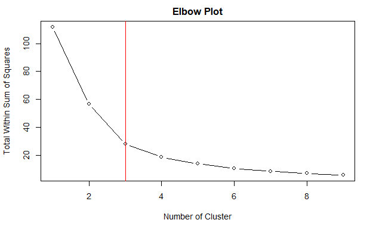

```r
jumlah_klaster <- c(1:9) #Vektor yang berisikan jumlah klaster yang ingin dilihat nilai dari total within-cluster sum of squares
within_ss <- c() #Vektor kosong yang akan diisi nilai total within- cluster sum of squares
for (i in jumlah_klaster) {
  within_ss <- c(within_ss, kmeans(x = data_standardized1, centers = i, nstart = 25)$tot.withinss)
}
plot(x = jumlah_klaster, y = within_ss, type = "b", xlab = "Number of Cluster",ylab = "Total Within Sum of Squares",main = "Elbow Plot" )
abline(v = 3, col = 'red')
```

```r
dist_data10.1 <- dist(data_standardized1)
str(dist_data10.1)
```

```
 'dist' num [1:406] 3.02 2.15 1.85 1.95 6.06 ...
 - attr(*, "Size")= int 29
 - attr(*, "Diag")= logi FALSE
 - attr(*, "Upper")= logi FALSE
 - attr(*, "method")= chr "euclidean"
 - attr(*, "call")= language dist(x = data_standardized1)
```

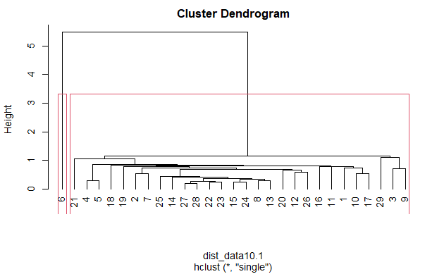

```r
#single linkage dengan scale
res1_par <- hclust(dist_data10.1,method = "single")
plot(res1_par,hang=-2,cex=1)
rect.hclust(res1_par,k=2)
```

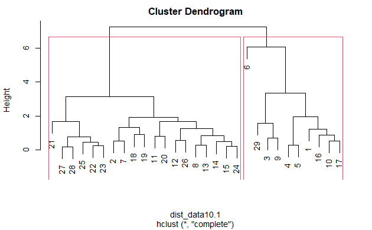

```r
#complete linkage dengan scale
res2_par <- hclust(dist_data10.1,method="complete")
plot(res2_par)
rect.hclust(res2_par,k=2)
```

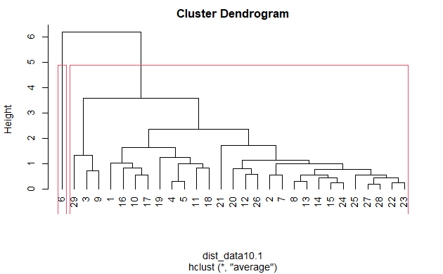

```r
#average linkage dengan scale
res3_par <- hclust(dist_data10.1,method="average")
plot(res3_par,hang=-2)
rect.hclust(res3_par,k=2)
```

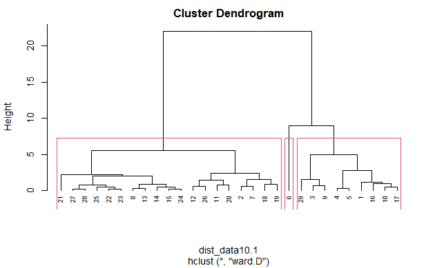

```r
#ward linkage
res4_par <- hclust(dist_data10.1,method = "ward.D")
plot(res4_par,hang=-1,cex=0.6)
rect.hclust(res4_par,k=3)
```

untuk single linkage, 3 cluster masih buruk karena terdapat 1 cluster yang berisi hanya 1 kabupaten/kota yaitu Biak Numfor (6). Setelah dicoba 2 cluster masih belum baik.

untuk complete linkage,3 cluster masih buruk karena terdapat 1 cluster yang berisi hanya 1 kabupaten/kota yaitu Biak Numfor (6). Setelah dicoba 2 kluster maka ditemukan pembagian kluster, kluster 1 : 6,29,3,9,4,5,1,16,10,17, kluster 2 : selebihnya.

untuk average linkage, 3 cluster masih buruk karena terdapat 1 cluster yang berisi hanya 1 kabupaten/kota yaitu Biak Numfor (6). Setelah dicoba 2 cluster masih belum baik.

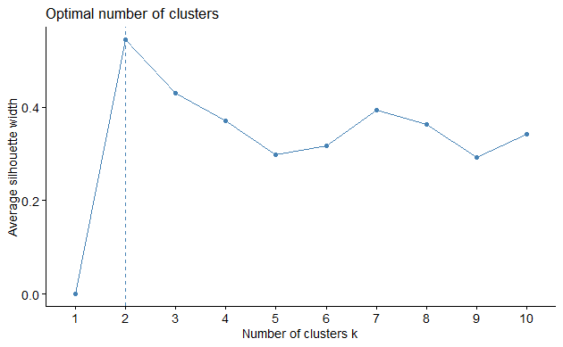

```r
library(factoextra)
library(gridExtra)
fviz_nbclust(data10.1[, c(2:5)], kmeans)
```

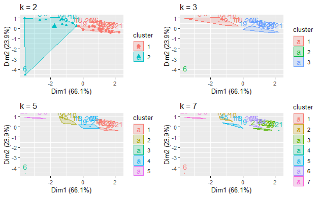

```r
##Plot K-means dengan scalling

kmeans2 <- kmeans(data_standardized1,centers = 2,nstart=25)
kmeans3 <- kmeans(data_standardized1,centers = 3,nstart=25)
kmeans5 <- kmeans(data_standardized1,centers = 5,nstart=25)
kmeans7 <- kmeans(data_standardized1,centers = 7,nstart=25)

#compare plot
plot1 <- fviz_cluster(kmeans2,geom=c("point", "text"),data=data_standardized1, show.clust.cent = TRUE) + ggtitle("k = 2")
plot2 <- fviz_cluster(kmeans3,geom="text",data=data_standardized1) + ggtitle("k = 3")
plot3 <- fviz_cluster(kmeans5,geom="text",data=data_standardized1) + ggtitle("k = 5")
plot4 <- fviz_cluster(kmeans7,geom="text",data=data_standardized1) + ggtitle("k = 7")
grid.arrange(plot1,plot2,plot3,plot4,nrow=2)
```

Dari kmeans cluster, terlihat bahwa pengelompokan baik terjadi ketika menggunakan 2 kelompok. hal ini dikarenakan pada kelompok ke 3, kabupaten ke 6 menjadi kelompok tersendiri dengan anggota 1.

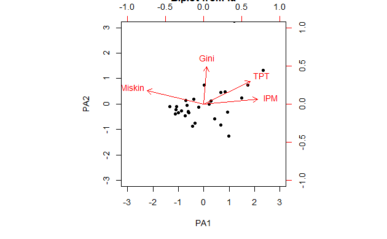

```r
fa1 <- fa(data10.1[,2:5], nfactors=2, fm="pa", scores=TRUE) # factor analysis 2 common factor
biplot(fa1)
```

```r
aggregate(data_standardized1,by=list(kmeans2$cluster),FUN=mean)
```

| Group.1 | Miskin | IPM | TPT | Gini |
| --- | --- | --- | --- | --- |
| 1 | 0.6514556 | -0.6111611 | -0.5749833 | -0.1956722 |
| 2 | -1.0660182 | 1.0000727 | 0.9408818 | 0.3201909 |